# victordiazb-A1

# Normalización de las variables cualitativas

A continuación, vamos a normalizar las variables cualitativas. Para ello, en primer lugar, vamos a convertir los datos a formato **título** mediante el uso de la función *str_to_title()*. Posteriormente, **eliminaremos espacios en blanco, tabulaciones y saltos de línea** presentes al inicio o al final del texto mediante la función *trimws()*, así como **espacios en blanco duplicados** entre palabras utilizando *gsub()* (*“\\s{2,}”* es una expresión regular que busca dos o más espacios en blanco) y **acentos** utilizando la función *iconv()*. Finalmente, mostraremos la **tabla de frecuencias** de cada variable con la función *table()*.

```r
# Convertir a título
data$Region <- str_to_title(data$Region)
data$Country <- str_to_title(data$Country)

# Registrar cambios a formato titulo
id_registro <- id_registro + 1
historial <- rbind(historial, data.frame("id" = id_registro, "fila" ="\\*", "mensaje" = "Variables Region y Country convertidas a formato titulo"))
```

```r
# Filas con espacios y tabulaciones o saltos de línea al principio y al final del contenido
ids_region <- which(trimws(data$Region) != data$Region)
ids_country <- which(trimws(data$Country) != data$Country)

# Quitar espacios y tabulaciones o saltos de línea al principio y al final del contenido
data$Region <- trimws(data$Region)
data$Country <- trimws(data$Country)

# Registrar cambios
if(length(ids_region) > 0){
  id_registro <- id_registro + 1
  historial <- rbind(historial, data.frame("id" = id_registro, "fila" = paste(ids_region, collapse = ","), "mensaje" = "Eliminados espacios y tabulaciones o saltos de línea al principio y al final del contenido en la variable Region"))
}
if(length(ids_country) > 0){
  id_registro <- id_registro + 1
  historial <- rbind(historial, data.frame("id" = id_registro, "fila" = paste(ids_country, collapse = ","), "mensaje" = "Eliminados espacios y tabulaciones o saltos de línea al principio y al final del contenido en la variable Country"))
}
```

```r
# Filas con espacios en blanco duplicados
ids_region <- which(gsub("\\s{2,}", " ", data$Region) != data$Region)
ids_country <- which(gsub("\\s{2,}", " ", data$Country) != data$Country)

# Dejar un espacio en blanco entre palabras
data$Region <- gsub("\\s{2,}", " ", data$Region)
data$Country <- gsub("\\s{2,}", " ", data$Country)

# Registrar cambios
if(length(ids_region) > 0){
  id_registro <- id_registro + 1
  historial <- rbind(historial, data.frame("id" = id_registro, "fila" = paste(ids_region, collapse = ","), "mensaje" = "Eliminados espacios duplicados en la variable Region"))
}
if(length(ids_country) > 0){
  id_registro <- id_registro + 1
  historial <- rbind(historial, data.frame("id" = id_registro, "fila" = paste(ids_country, collapse = ","), "mensaje" = "Eliminados espacios duplicados en la variable Country"))
}
```

```r
# Filas con acentos
ids_region <- which(iconv(data$Region) != data$Region)
ids_country <- which(iconv(data$Country) != data$Country)

# Eliminar acentos
data$Region <- iconv(data$Region)
data$Country <- iconv(data$Country)

# Registrar cambios
if(length(ids_region) > 0){
  id_registro <- id_registro + 1
  historial <- rbind(historial, data.frame("id" = id_registro, "fila" = paste(ids_region, collapse = ","), "mensaje" = "Eliminados acentos en la variable Region"))
}
if(length(ids_country) > 0){
  id_registro <- id_registro + 1
  historial <- rbind(historial, data.frame("id" = id_registro, "fila" = paste(ids_country, collapse = ","), "mensaje" = "Eliminados acentos en la variable Country"))
}
```

```r
# Mostrar tabla de frecuencias
print(table(head(data$Country, 20)))
```

```
##
##     Australia       Austria       Belgium        Brazil        Canada
##             1             1             1             1             1
##    Costa Rica       Denmark       Finland       Germany       Iceland
##             1             1             1             1             1
##       Ireland        Israel    Luxembourg   Netherlands   New Zealand
##             1             1             1             1             1
##        Norway   Puerto Rico        Sweden   Switzerland United States
##             1             1             1             1             1
```

```r
print(table(data$Region))
```

```
##
##       Australia And New Zealand      Central And Eastern Europe
##                               2                              29
##                    Eastern Asia     Latin America And Caribbean
##                               6                              24
##  Middle East And Northern Afrca Middle East And Northern Africa
##                               5                              14
##                   North America               Southeastern Asia
##                               2                               9
##                   Southern Asia               Sub-Saharan Afrca
##                               7                              13
##              Sub-Saharan Africa                  Western Europe
##                              25                              21
```

Vemos que hay **errores sintácticos** como *“Middle East And Northern Afrca”* y *“Sub-Saharan Afrca”* en la variable Region que reemplazaremos por *“Middle East And Northern Africa”* y *“Sub-Saharan Africa”*, respectivamente, mediante el uso de la función *gsub()* que busca las cadenas de texto especificadas como primer argumento y las reemplaza con las cadenas especificadas como segundo argumento..

```r
# Filas con errores sintácticos
ids <- which(grepl("Afrca", data$Region))

# Reemplazar errores sintácticos
data$Region <- gsub("Afrca", "Africa", data$Region)

# Registrar cambios
if(length(ids) > 0){
  id_registro <- id_registro + 1
  historial <- rbind(historial, data.frame("id" = id_registro, "fila" = paste(ids_region, collapse = ","), "mensaje" = "Eliminados errores sintacticos en la variable Region"))
}

# Mostrar nueva tabla de frecuencias
print(table(data$Region))
```

```
##
##       Australia And New Zealand      Central And Eastern Europe
##                               2                              29
##                    Eastern Asia     Latin America And Caribbean
##                               6                              24
## Middle East And Northern Africa                   North America
##                              19                               2
##               Southeastern Asia                   Southern Asia
##                               9                               7
##              Sub-Saharan Africa                  Western Europe
##                              38                              21
```

Por último, reemplazaremos los textos “And” por “and” con *gsub()*.

```r
# Filas con "errores sintácticos "And"
ids_region <- which(grepl("And", data$Region))
ids_country <- which(grepl("And", data$Country))

# Reemplazar "And" por "and"
data$Region <- gsub("And", "and", data$Region)
data$Country <- gsub("And", "and", data$Country)

# Registrar cambios
if(length(ids_region) > 0){
  id_registro <- id_registro + 1
  historial <- rbind(historial, data.frame("id" = id_registro, "fila" = paste(ids_region, collapse = ","), "mensaje" = "Reemplaza 'And' por 'and' en la variable Region"))
}
if(length(ids_country) > 0){
  id_registro <- id_registro + 1
  historial <- rbind(historial, data.frame("id" = id_registro, "fila" = paste(ids_country, collapse = ","), "mensaje" = "Reemplaza 'And' por 'and' en la variable Country"))
}

# Mostrar nueva tabla de frecuencias
print(table(data$Region))
```

```
##
##       Australia and New Zealand      Central and Eastern Europe
##                               2                              29
##                    Eastern Asia     Latin America and Caribbean
##                               6                              24
## Middle East and Northern Africa                   North America
##                              19                               2
##               Southeastern Asia                   Southern Asia
##                               9                               7
##              Sub-Saharan Africa                  Western Europe
##                              38                              21
```

```r
print(table(head(data$Country, 20)))
```

```
##
##     Australia       Austria       Belgium        Brazil        Canada
##             1             1             1             1             1
##    Costa Rica       Denmark       Finland       Germany       Iceland
##             1             1             1             1             1
##       Ireland        Israel    Luxembourg   Netherlands   New Zealand
##             1             1             1             1             1
##        Norway   Puerto Rico        Sweden   Switzerland United States
##             1             1             1             1             1
```

# Estudio de inconsistencia entre variables

En este apartado vamos a buscar inconsistencias entre los pares de variables HR-HS y LCI-UCI. En caso de inconsistencia entre las variables HR y HS, se tomará como dato correcto el correspondiente a la variable HS y por tanto, habrá que rectificar los valores erróneos de HR. La inconsistencia entre las variables LCI y UCI, se observará cuando el valor LCI sea mayor a UCI. En estos casos, se procederá a intercambiar los valores.

## HR vs HS

En primer lugar vamos a buscar inconsistencias entre HR y HS. Para ello, vamos a ordenar los datos por orden descendente de HS utilizando la función *arrange()* para ordenar nos datos y *desc()* para indicar el orden descendente. Posteriormente, se comprueba que la posición de cada dato en ese orden coincide con su valor de HR, en caso contrario, es una inconsistencia y, por tanto, se debe reemplazar el valor de HR por el de esta posición.

```r
# Ordenar por HS
data <- arrange(data, desc(HS))

# Obtener inconsistencias, compara valor de HR con su posición en un HS ordenado
ids <- which(data$HR != as.integer(row.names(data)))

# Guardar datos en un dataframe
inconsistencias <- data.frame("HR_original"=data[ids, "HR"],"HR_esperado"=as.integer(row.names(data[ids,])))

# Si hay inconsistencias
if (length(ids) > 0) {
  # Corregir valores de HR
  data$HR <- as.integer(row.names(data))
  cat("Se han corregido", length(ids), "valores incorrectos en HR.\n")
  print(inconsistencias)

  # Registrar cambios
  id_registro <- id_registro + 1
  historial <- rbind(historial, data.frame("id" = id_registro, "fila" = paste(ids, collapse = ","), "mensaje" = "Inconsistencias corregidas en las variables HS y HR"))

} else {
  cat("Los valores de HR son consistentes con el orden de HS.\n")
}
```

```
## Se han corregido 9 valores incorrectos en HR.
##   HR_original HR_esperado
## 1          61           2
## 2          34          35
## 3          57          58
## 4           2          59
## 5          81          61
## 6          59          72
## 7         140          81
## 8          72         140
## 9         145         146
```

## LCI vs UCI

A continuación, buscamos inconsistencias en las variables LCI y UCI. Para ello, comparamos los valores de ambas columnas y, en los casos en los que el valor de LCI sea mayor que UCI, se intercambiarán estos valores.

```r
# Se buscan inconsistencias
ids <- which(data$LCI > data$UCI)

if(length(ids) > 0){
  # Obtener los valores máximos y mínimos entre UCI y LCI
  max_vals <- pmax(data$UCI, data$LCI)
  min_vals <- pmin(data$UCI, data$LCI)

  # Asignar los valores máximos y mínimos a las variables correspondientes
  data$UCI <- max_vals
  data$LCI <- min_vals

  cat("Se han corregido", length(ids), "inconsistencias ente UCI y LCI.\n")

  # Registrar cambios
  id_registro <- id_registro + 1
  historial <- rbind(historial, data.frame("id" = id_registro, "fila" = paste(ids, collapse = ","), "mensaje" = "Inconsistencias corregidas en las variables UCI y LCI"))
} else {
  print("Los valores de UCI y LCI son consistentes.\n")
}
```

```
## Se han corregido 12 inconsistencias ente UCI y LCI.
```

# Valores atípicos

## Revisar valores atípicos

En este apartado vamos a buscar valores atípicamente altos o bajos en las variables HS, GC, Generosity y Family, los cuales consideraremos valores anómalos y los reemplazaremos por el valor nulo (*NA*). Para ello, vamos a utilizar la función *boxplot.stats()*, que calcula estadísticas de resumen sobre los datos y devuelve un objeto con las siguientes componentes: “stats” (los valores mínimo, primer cuartil, mediana, tercer cuartil y máximo), “n” (el número de observaciones), “conf” (un intervalo de confianza para la mediana) y “out” (los valores atípicos). Por otro lado, la función *boxplot()* nos permite visualizar un diagrama de caja y bigotes y ver así fácilmente los percentiles y los outliers.

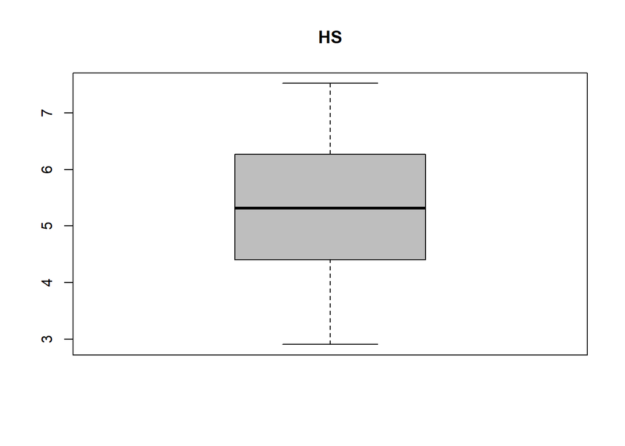

```
## [1] "No valores atipicos para esta variable."
```

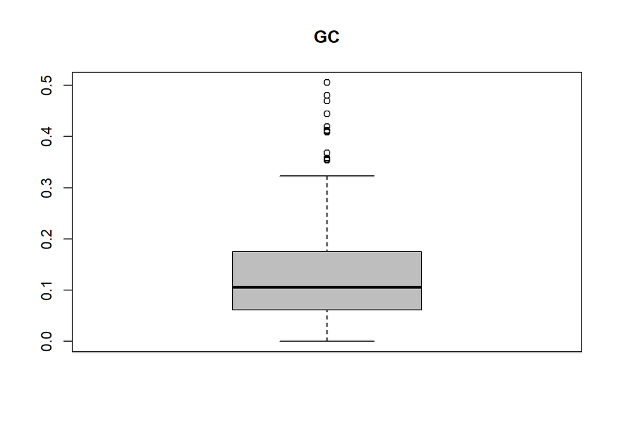

```
## Valores atipicos:  0.35329 0.35561 0.35776 0.36794 0.40867 0.41004 0.41203 0.41904 0.44453 0.46987 0.48049 0.50521
```

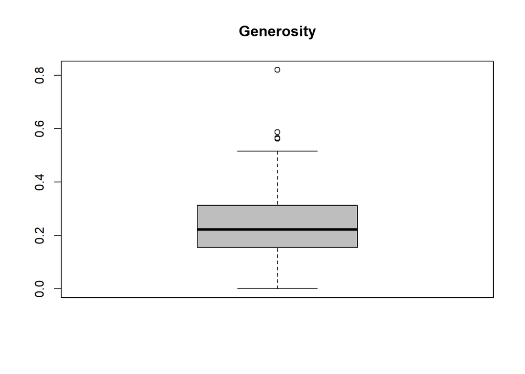

```
## Valores atipicos:  0.56237 0.56521 0.58696 0.81971
```

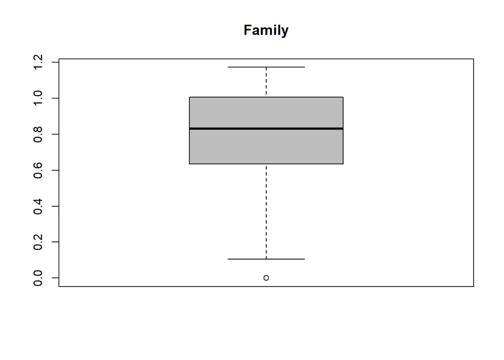

```
## Valores atipicos:  0
```

```r
total_indices_atipicos = c()
for (i in c("HS", "GC", "Generosity", "Family")){
  # Mostrar diagrama de cajas
  boxplot(data[[i]],main=i, col="gray")

  # Mostrar valores atípicos
  x<-boxplot.stats(data[[i]])$out
  ids <- which(data[[i]] %in% x)
  listaAtipicos <- sort(data[[i]][ids])

  if(length(listaAtipicos) > 0){
    total_indices_atipicos <-  append(total_indices_atipicos, ids, after = length(total_indices_atipicos))
    cat("Valores atipicos: ", listaAtipicos, "\n")

    # Sustituir valores atípicos por valores nulos
    data[[i]] <- ifelse(data[[i]] %in% listaAtipicos, NA, data[[i]])

    # Registrar cambios
    id_registro <- id_registro + 1
    historial <- rbind(historial, data.frame("id" = id_registro, "fila" = paste(ids, collapse = ","), "mensaje" = paste("Valores atípicos reemplazados por valor nulo en la variable ", i)))

  }
  else{
    print("No valores atipicos para esta variable.")
  }
}
```

## Identificar a qué paises pertenecen los valores atípicos encontrados

```r
cat("Los valores atípicos detectados pertenecen a los siguientes paises: ", data[total_indices_atipicos,"Country"])
```

```
## Los valores atípicos detectados pertenecen a los siguientes paises:  Denmark Switzerland Norway Finland New Zealand Sweden Luxembourg Singapore United Arab Emirates Qatar Somaliland Region Rwanda Malta Thailand Indonesia Myanmar Togo
```

# Imputación de valores

A continuación, procedemos a buscar si hay valores perdidos (*NAs*) en las variables cuantitativas. Para ello, usaremos la función *is.na()* de R. En el caso de detectar alguno, es necesario realizar una imputación de valores en estas variables. Aplicaremos imputación por vecinos más cercanos, utilizando la distancia de Gower, considerando en el cómputo de los vecinos más cercanos el resto de variables cuantitativas.

La distancia de **Gower** es una medida de distancia utilizada en el análisis de datos multivariados para calcular la distancia entre dos objetos. Se calcula como la suma de las distancias ponderadas de las variables individuales, donde cada variable tiene un peso igual al inverso del número de valores distintos para esa variable en el conjunto de datos. Por ejemplo, si una variable categórica tiene 5 valores distintos en el conjunto de datos, su peso sería 1/5. La distancia Gower tiene la ventaja de poder manejar datos de diferentes tipos y escalas, lo que la hace útil en problemas de clustering y análisis de datos heterogéneos. Además, es una medida de distancia simétrica, es decir, la distancia entre dos objetos es la misma independientemente del orden en que se consideren.

$D_{x_{i}x_{j}} = \frac{\sum_{r=1}^{p}W_{x_{i}x_{j}z_{r}}D_{x_{i}x_{j}z_{r}}}{\sum_{r=1}^{p}W_{x_{i}x_{j}z_{r}}} + \frac{\sum_{r=1}^{q-p}W_{x_{i}x_{j}c_{r}}D_{x_{i}x_{j}c_{r}}}{\sum_{r=1}^{q-p}W_{x_{i}x_{j}c_{r}}}$

Donde $x_{i}$ y $x_{j}$ representan dos objetos o individuos en el conjunto de datos que se están comparando. $W_{x_{i}x_{j}z_{r}}$ y $W_{x_{i}x_{j}c_{r}}$ son los pesos para las variables categóricas ($z_{r}$) y continuas ($c_{r}$), respectivamente. $D_{x_{i}x_{j}z_{r}}$ es la distancia Manhattan a lo largo de una variable categórica $z_{r}$ que puede obtenerse como

$$D_{x_{i}x_{j}z_{r}} =
\begin{cases}
0, & \text{si } z_{r}^{i} = z_{r}^{j} \\
1, & \text{si } z_{r}^{i} \neq z_{r}^{j} \\
\end{cases}$$

$D_{x_{i}x_{j}c_{r}}$ es la distancia Manhattan a lo largo de una variable contínua $c_{r}$ que puede obtenerse como $D_{x_{i}x_{j}c_{r}} = \frac{|c_{r}^{i} - c_{r}^{j}|}{max(c_{r}) - min(c_{r})}$.

Aunque la distancia Manhattan se utiliza en el cálculo de la disimilitud original de Gower, pueden utilizarse otras métricas de distancia.

**[ref]** *Gulanbaier Tuerhong, Seoung Bum Kim. (2014). “Gower distance-based multivariate control charts for a mixture of continuous and categorical variables”. Expert Systems with Applications. Volume 41, Issue 4, Part 2. Pages 1701-1707.* (https://www.sciencedirect.com/science/article/pii/S0957417413006891)

Para realizar esta imputación, se puede usar la función *kNN()* de la librería VIM con un número de vecinos igual a 11. Esta función realiza imputación por vecinos más cercanos para datos faltantes en un conjunto de datos. Utiliza la distancia de Gower para calcular la distancia entre los diferentes puntos del conjunto de datos, y después encuentra los vecinos más cercanos de cada punto que tenga datos faltantes, basándose en las variables que sí tienen datos para calcular la distancia.

```r
# Motrar número de NAs en cada columna
print(colSums(is.na(data)))
```

```
##    Country     Region         HR         HS        LCI        UCI        GpC
##          0          0          0          0          0          0          0
##     Family         LE    Freedom         GC Generosity
##          6          0          0         12          4
```

```r
# Imputar valores mediante KNN con k=11
data <- kNN(data, k=11)
print(str(data))
```

```
## 'data.frame':    157 obs. of  24 variables:
##  $ Country       : chr  "Denmark" "Switzerland" "Iceland" "Norway" ...
##  $ Region        : chr  "Western Europe" "Western Europe" "Western Europe" "Western Europe" ...
##  $ HR            : int  1 2 3 4 5 6 7 8 9 10 ...
##  $ HS            : num  7.53 7.51 7.5 7.5 7.41 ...
##  $ LCI           : num  7.46 7.43 7.33 7.42 7.35 ...
##  $ UCI           : num  7.59 7.59 7.67 7.58 7.47 ...
##  $ GpC           : num  1.44 1.53 1.43 1.58 1.41 ...
##  $ Family        : num  1.16 1.15 1.02 1.13 1.13 ...
##  $ LE            : num  0.795 0.863 0.867 0.796 0.811 ...
##  $ Freedom       : num  0.579 0.586 0.566 0.596 0.571 ...
##  $ GC            : num  0.258 0.258 0.15 0.213 0.237 ...
##  $ Generosity    : num  0.362 0.281 0.477 0.379 0.255 ...
##  $ Country_imp   : logi  FALSE FALSE FALSE FALSE FALSE FALSE ...
##  $ Region_imp    : logi  FALSE FALSE FALSE FALSE FALSE FALSE ...
##  $ HR_imp        : logi  FALSE FALSE FALSE FALSE FALSE FALSE ...
##  $ HS_imp        : logi  FALSE FALSE FALSE FALSE FALSE FALSE ...
##  $ LCI_imp       : logi  FALSE FALSE FALSE FALSE FALSE FALSE ...
##  $ UCI_imp       : logi  FALSE FALSE FALSE FALSE FALSE FALSE ...
##  $ GpC_imp       : logi  FALSE FALSE FALSE FALSE FALSE FALSE ...
##  $ Family_imp    : logi  FALSE FALSE TRUE FALSE FALSE FALSE ...
##  $ LE_imp        : logi  FALSE FALSE FALSE FALSE FALSE FALSE ...
##  $ Freedom_imp   : logi  FALSE FALSE FALSE FALSE FALSE FALSE ...
##  $ GC_imp        : logi  TRUE TRUE FALSE TRUE TRUE FALSE ...
##  $ Generosity_imp: logi  FALSE FALSE FALSE FALSE FALSE FALSE ...
## NULL
```

```r
# Filas imputadas
ids <- which(apply(data, 1, function(x) any(x == TRUE)))

# Registrar cambios
if(length(ids) > 0){
  id_registro <- id_registro + 1
  historial <- rbind(historial, data.frame("id" = id_registro, "fila" = paste(ids, collapse = ","), "mensaje" = "Valores nulos imputados"))
}
```

Eliminamos las nuevas columnas agregadas.

```r
# Eliminar las nuevas columnas agregadas
data <- data[1:(length(data)/2)]

# Registrar cambios
id_registro <- id_registro + 1
historial <- rbind(historial, data.frame("id" = id_registro, "fila" ="", "mensaje" = "Filas agregadas por kNN no utilizas eliminadas"))
```

Mostramos que la imputación se ha realizado correctamente, visualizando el resultado de los datos afectados por la imputación.

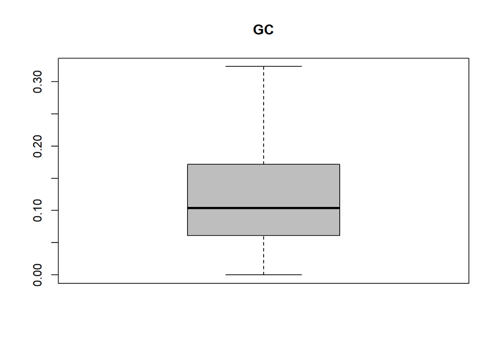

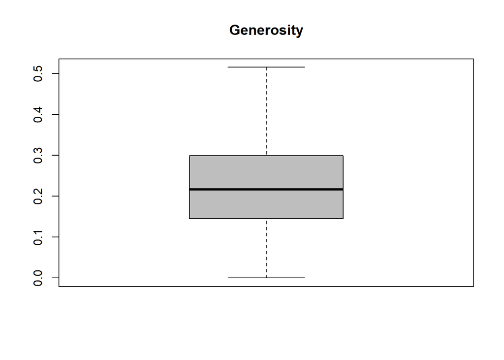

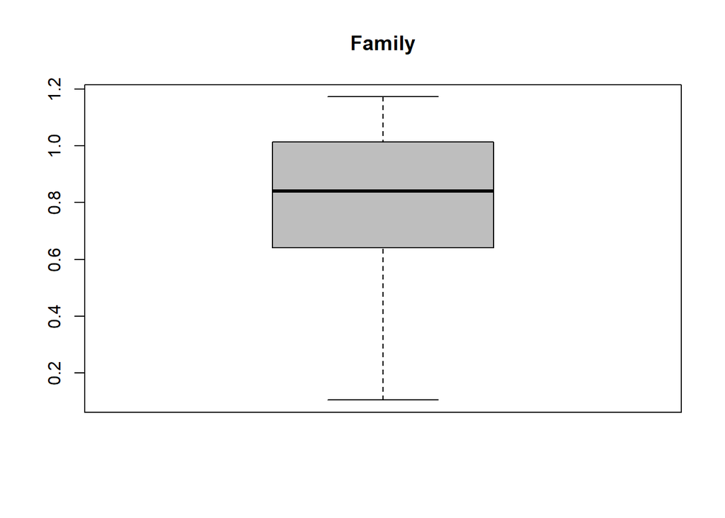

```r
for (i in c("GC", "Generosity", "Family")){
  # Mostrar diagrama de cajas
  boxplot(data[[i]],main=i, col="gray")
}
```

Vemos que los valores atípicos han desaparecido.

Además, gracias a usar kNN en vez de la imputación básica mediante el valor **promedio**, se tienen en cuenta la estructura de los datos y las relaciones entre variables, dando mayor precisión a los datos imputados.

Esto se podría lograr también con un modelo de **regresión lineal**, pero kNN puede ser más robusta que una regresión lineal cuando no se cumple la suposición de linealidad en los datos, ya que k-NN no asume una relación lineal entre las variables predictoras y la variable de interés, aunque la imputación por regresión lineal puede llegar a ser más precisa si se dan estas condiciones.

# Estudio descriptivo

## Representación gráfica de variables

En este apartado, vamos a representar gráficamente los datos de la variable Freedom en función de la variable Region. Para ello, lo más sencillo es hacer un gráfico de barras con estas dos variables. Utilizamos la función *aggregate()* para agrupar los datos de Freedom en función de Region y, posteriormente, con las funciones de la libreria *ggplot2* creamos el gráfico de barras.

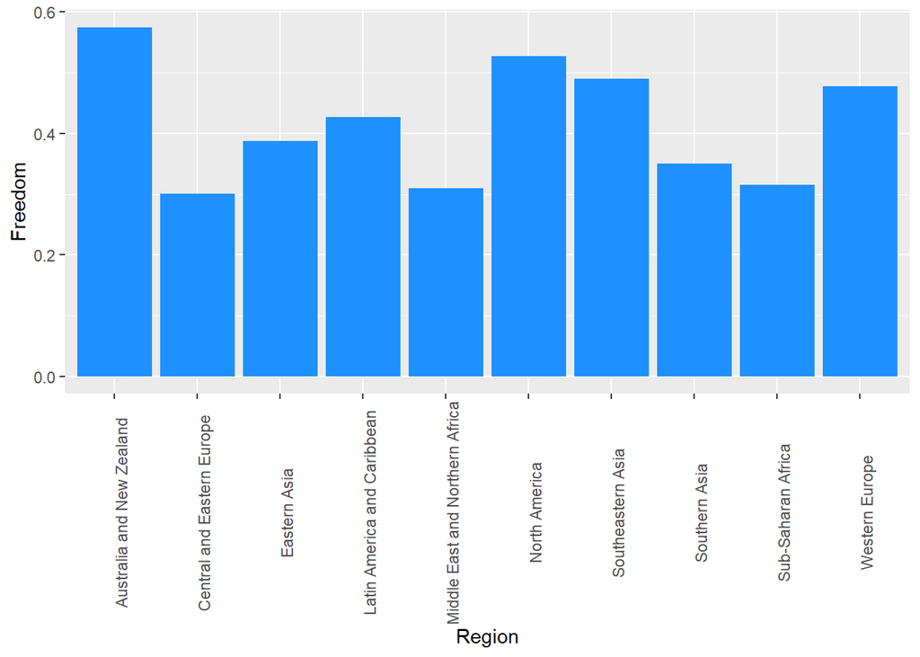

```r
# Agrupar por region y calcular la media de la variable Freedom
avg_data <- aggregate(Freedom ~ Region, data, "mean")

# Hacer el barplot
ggplot(avg_data, aes(x = Region, y = Freedom)) +
  geom_bar(stat = "identity", fill = "#1E90FF") +
  labs(x = "Region", y = "Freedom") +
  theme(axis.text.x = element_text(angle = 90)) # Rotar etiquetas 90º
```

Una representación más avanzada y compleja puede ser mostrar estos datos en un mapa, dando un color a cada país en función de la región a la que pertenezca y de su grado de libertad. Aunque esto no es necesario, puede ser muy interesante y visual de cara a su análisis. Para ello, utilizamos las funciones de la librería *maps*.

```r
# Obtener los nombres de las regiones predefinidas en el paquete maps
nombres_paises <- map("world", plot = FALSE, fill = TRUE)$names

# Añado columna de paises a las regiones
avg_data.countries <- merge(data[c("Country","Region")], avg_data, by = "Region")

# Cambio de formato
avg_data.countries$Country <- gsub("United States*", "USA", avg_data.countries$Country)

# Muestro los paises sin coincidencias con los nombres del mapa
cat("Paises que no se han podido representar: {", subset(avg_data.countries, !Country %in% nombres_paises)$Country, "}\n")
```

```
## Paises que no se han podido representar: { New Zealand Tajikistan Macedonia Japan Hong Kong Trinidad and Tobago Palestinian Territories Indonesia Malaysia Philippines Malawi Somaliland Region Congo (Kinshasa) Comoros Congo (Brazzaville) North Cyprus United Kingdom }
```

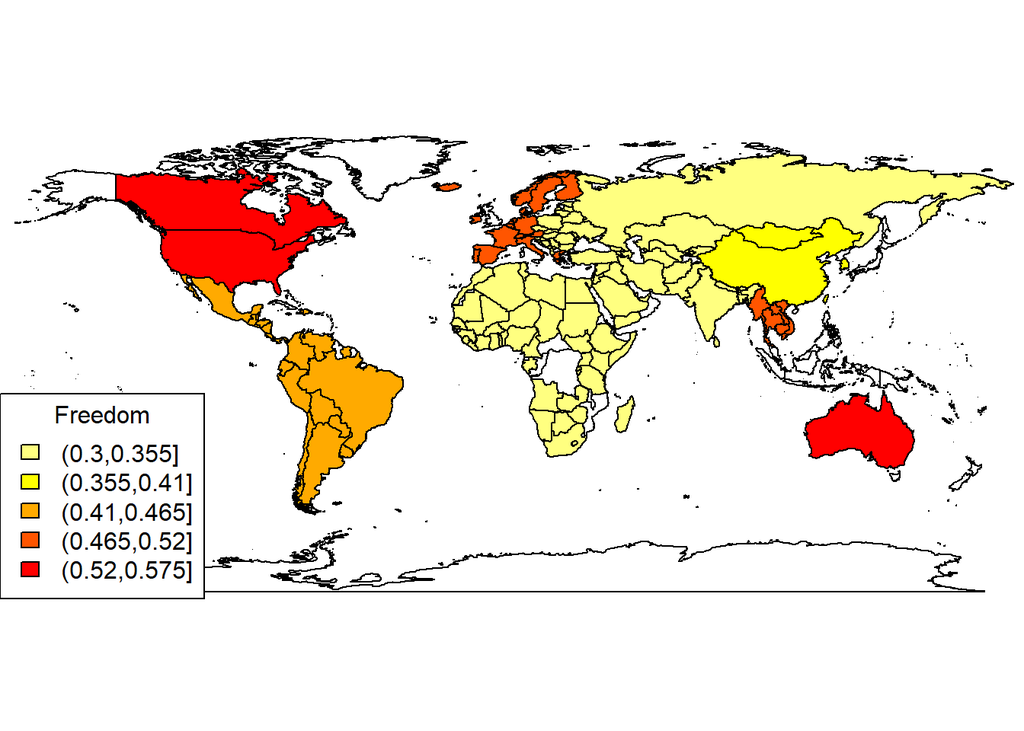

```r
# Elimino paises que no tengan coincidencias con los nombres del mapa
avg_data.countries <- subset(avg_data.countries,Country %in% nombres_paises)

# Crear un vector de colores según los valores de "Freedom"
colores <- rev(heat.colors(5))[as.numeric(cut(avg_data.countries$Freedom, breaks = 5))]

# Crear el mapa y colorear las regiones según los datos de "Freedom"
map("world", fill = TRUE, col = colores[match(nombres_paises, avg_data.countries$Country)], resolution = 0, mar = c(0, 0, 0, 0))

# Añadir una leyenda
legend("bottomleft", legend = levels(cut(avg_data.countries$Freedom, breaks = 5)), fill = rev(heat.colors(5)), title = "Freedom")
```

Aquí podemos ver otra representación gráfica. Aunque faltan algunos paises, debido a diferencias de formato, ofrece una visión muy representativa de los datos.